# January 2022

`pandoc --self-contained summary.md -o test.html`

Some changes: - Wrap up all post-processing scripts (imputation of missing values; pca; etc.) into one bash script. - Move to python for as much of the processing as possible - Put python scripts in `code/python_scripts` for organization - Take command line arguments - Integrate with GNU parallel as much as possible

Progress - Pools 6 and 7 are completely unpacked

Quick To-do - Md5sum checking on first 100 - Restructure to pools instead of groups for first 100 - QC reports into their respective directories

## January 4, 2022

On imputation: - May not be computationally efficient, but imputing methylated reads separately from coverage may be the most sound - Correlation between methylated and coverage: 0.68 - Correlation between methylated and unmethylated: -0.63 - Correlation between unmethylated and coverage: - Two poles: 1. A sample has unique information: perhaps its a SNP or SNV; synonymous or non-synonymous? Who knows. 2. Accounting for sequencing errors - There tends to be bimodality. The vast majority of positions have estimates for 100% of sites; but there is some probability (small) that there is a missing estimate. Basically a binomial distribution; but then the marginal increase (the extra counts with lots of missing) are information dense– IDEA: - handle coverage and methylation estimate separately?? 1. Cluster each site: is it part of the binomial distribution? Or is it from the “signature methulation estimate” population? 2. Separate the two populations. - If it’s part of the binomial (say above 0.5 probability (this would be a user-specified parameter)) then we impute with local mean; or likelihood based; or whatever method you want (some form of rolling average or perhaps the linear regression version advocated in that paper) - If it’s part of the signature population; set it aside; it could be part of the information-rich population of CpG traffic lights; could be a (small) island; or could be a really bad sequencing error.

# January 18 2022 (LOAD Update)

1. Do (the same) outliers show up in array data?
2. Can we get better estimates

## 1. Outliers

Recall the two outliers we’ve seen (samples 101 and 126):

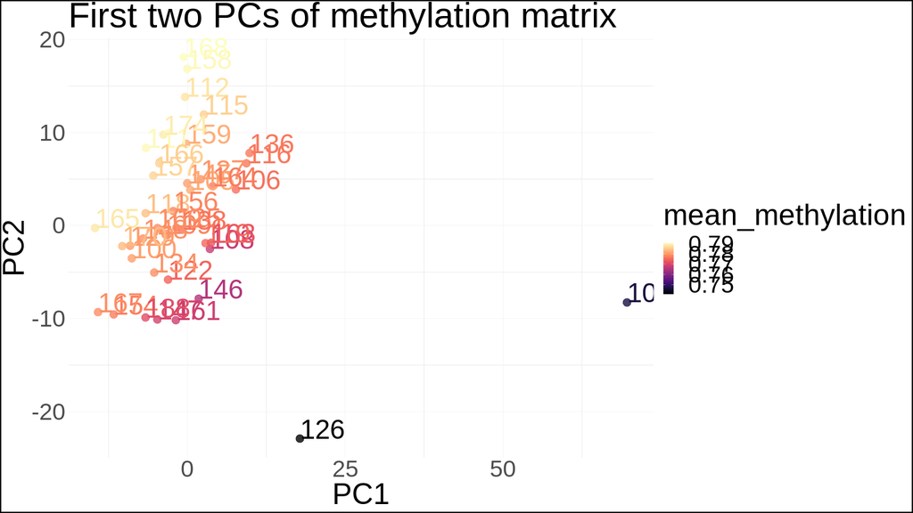

101 is a clear outlier in array data:

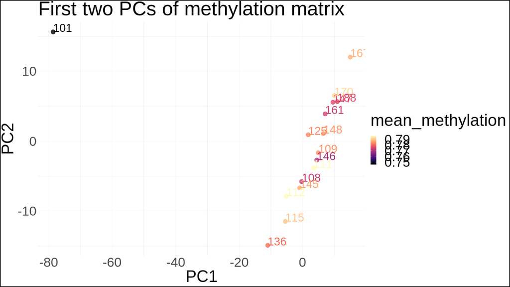

Unfortunate;y, 126 is not in array data. Likely drop these two from analysis? Probably won’t make the final decision until we can see the entire sample of 375-ish.

(Paper that reviews deconvolution methods)[https://www.ncbi.nlm.nih.gov/pmc/articles/PMC5886462/pdf/ddx275.pdf] - Nerual network based (seems excessive but don’t know details) - Reference based (used 450K reference for 850K data–since Andy’s paper there has been a reference dataset published for 850K (here)[https://pubmed.ncbi.nlm.nih.gov/30232931/] but its for neonatal cord blood)

## 2. Improving Estimate of Methylation

## Idea

- fit a glm at each CpG locus to create better methylation estimates.
- account for variability in *cell composition* specifically.

## Implementation notes

- logit link function
- Two models:
  1. Cell composition only (with mean_methylation)
  2. Cell composition (with mean_methylation) *and* age, sex, BMI
- Used *methylation estimate* as the response (as opposed to # methylated reads)

## Improvement

- Beta-binomial distribution with arc-sine

## Result

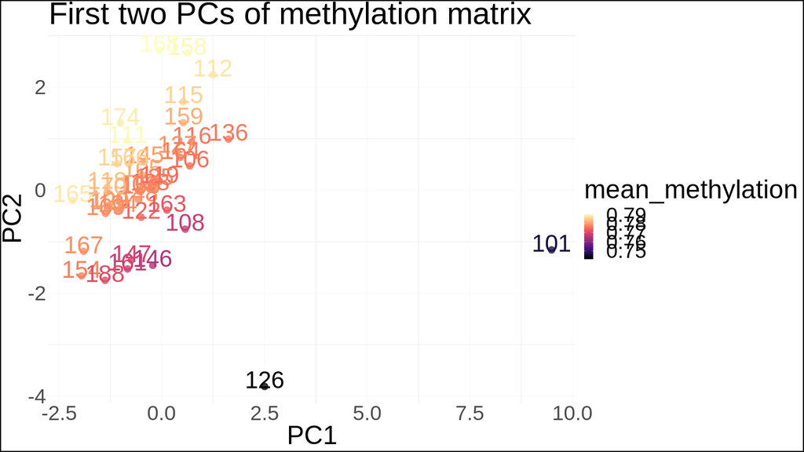

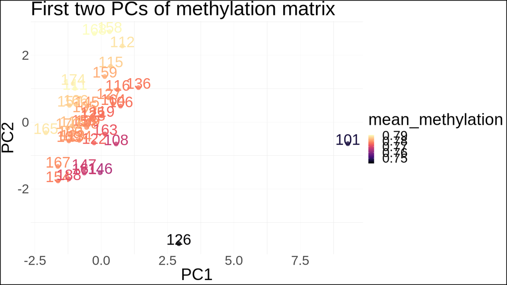

## Follow-up

Better GLM probably